# AE 02 - Bechdel Test

Spencer Robbins

2026-02-21

## Introduction

In this mini analysis we work with the data used in the FiveThirtyEight story titled [“The Dollar-And-Cents Case Against Hollywood’s Exclusion of Women”](https://fivethirtyeight.com/features/the-dollar-and-cents-case-against-hollywoods-exclusion-of-women/).

**The Bechdel Test** is a measure of the representation of women in fiction. A movie passes the test if it meets three criteria: 1. It has at least two women in it 2. Who talk to each other 3. About something other than a man

**In this application exercise, you will:**

- Practice data filtering and summarizing
- Calculate return on investment (ROI)
- Create and interpret boxplots
- Use grouping to compare categories
- Practice using inline R code
- Interpret relationships between variables

**Estimated time:** 30-45 minutes

## Getting Started

### Fork and Clone Workflow

**IMPORTANT:** Just like AE 01, you need to work in YOUR forked repository.

**Quick reminder:** 1. Make sure you forked `application-exercises` repository (you only do this once!) 2. You should be working in YOUR fork: `YourUsername/application-exercises` 3. Navigate to the `ae-02-bechdel` folder 4. Open `ae-02-bechdel.Rmd` 5. Update the YAML with your name 6. Click **Knit** to verify it works

**If you haven’t forked yet:** See detailed instructions in AE 01.

## Data and Packages

We start with loading the packages we’ll use.

```r
library(fivethirtyeight)
library(tidyverse)
```

**What these packages do:** - **fivethirtyeight:** Contains datasets from FiveThirtyEight articles - **tidyverse:** Data wrangling and visualization

### About the Data

The dataset contains information on 1794 movies released between 1970 and 2013. However, we’ll focus our analysis on movies released between 1990 and 2013.

```r
bechdel90_13 <- bechdel %>%
  filter(between(year, 1990, 2013))
```

**What this code does:** - `filter()`: Keeps only rows meeting a condition - `between()`: Checks if a value is between two numbers (inclusive) - Result: Movies from 1990-2013 only

## Exercise 1: Count the Movies

How many movies are in our filtered dataset?

There are 1615 movies in our filtered datas et.

**Fill in the blank using inline code:**

There are 1615 movies in our dataset.

**Hint:** Use inline R code with `nrow(bechdel90_13)` in your narrative text.

## Understanding the Variables

The financial variables we’ll focus on are the following:

- `budget_2013`: Budget in 2013 inflation adjusted dollars
- `domgross_2013`: Domestic gross (US) in 2013 inflation adjusted dollars
- `intgross_2013`: Total International (i.e., worldwide) gross in 2013 inflation adjusted dollars

And we’ll also use the `binary` and `clean_test` variables for **grouping**:

- `binary`: Whether the movie passed (PASS) or failed (FAIL) the Bechdel test
- `clean_test`: More detailed result (ok, dubious, men, notalk, nowomen)

**Explore the data:**

```r
# View the structure
glimpse(bechdel90_13)
```

```
## Rows: 1,615
## Columns: 15
## $ year          <int> 2013, 2012, 2013, 2013, 2013, 2013, 2013, 2013, 2013, 20…
## $ imdb          <chr> "tt1711425", "tt1343727", "tt2024544", "tt1272878", "tt0…
## $ title         <chr> "21 & Over", "Dredd 3D", "12 Years a Slave", "2 Guns", "…
## $ test          <chr> "notalk", "ok-disagree", "notalk-disagree", "notalk", "m…
## $ clean_test    <ord> notalk, ok, notalk, notalk, men, men, notalk, ok, ok, no…
## $ binary        <chr> "FAIL", "PASS", "FAIL", "FAIL", "FAIL", "FAIL", "FAIL", …
## $ budget        <int> 13000000, 45000000, 20000000, 61000000, 40000000, 225000…
## $ domgross      <dbl> 25682380, 13414714, 53107035, 75612460, 95020213, 383624…
## $ intgross      <dbl> 42195766, 40868994, 158607035, 132493015, 95020213, 1458…
## $ code          <chr> "2013FAIL", "2012PASS", "2013FAIL", "2013FAIL", "2013FAI…
## $ budget_2013   <int> 13000000, 45658735, 20000000, 61000000, 40000000, 225000…
## $ domgross_2013 <dbl> 25682380, 13611086, 53107035, 75612460, 95020213, 383624…
## $ intgross_2013 <dbl> 42195766, 41467257, 158607035, 132493015, 95020213, 1458…
## $ period_code   <int> 1, 1, 1, 1, 1, 1, 1, 1, 1, 1, 1, 1, 1, 1, 1, 1, 1, 1, 1,…
## $ decade_code   <int> 1, 1, 1, 1, 1, 1, 1, 1, 1, 1, 1, 1, 1, 1, 1, 1, 1, 1, 1,…
```

```r
# See how many movies passed vs failed
bechdel90_13 %>%
  count(binary)
```

```
## # A tibble: 2 × 2
##   binary     n
##   <chr>  <int>
## 1 FAIL     862
## 2 PASS     753
```

**How many movies passed the test?** 753 movies passed.

**How many failed?** 862 movies failed.

## Analysis

### Binary Bechdel Test Results

Let’s take a look at how median budget and gross vary by whether the movie passed the Bechdel test, which is stored in the `binary` variable.

```r
bechdel90_13 %>%
  group_by(binary) %>%
  summarise(
    med_budget = median(budget_2013),
    med_domgross = median(domgross_2013, na.rm = TRUE),
    med_intgross = median(intgross_2013, na.rm = TRUE)
  )
```

```
## # A tibble: 2 × 4
##   binary med_budget med_domgross med_intgross
##   <chr>       <dbl>        <dbl>        <dbl>
## 1 FAIL    48385984.    57318606.    104475669
## 2 PASS    31070724     45330446.     80124349
```

**What this code does:** - `group_by(binary)`: Creates groups for PASS and FAIL - `summarise()`: Calculates summary statistics for each group - `median()`: Finds the middle value - `na.rm = TRUE`: Removes missing values before calculating

## Exercise 2: Interpret Binary Results

**Task 2.1:** Which movies have higher median budgets: those that pass or fail the Bechdel test?

**Your answer:**

Movies that fail the test have higher median budgets.

**Task 2.2:** Which movies have higher median domestic gross: those that pass or fail?

**Your answer:**

Movies that fail the test have higher median domestic gross.

**Task 2.3:** What might explain these patterns?

**Your answer:**

Since many of the high budget films are more action and male lead focused it makes these less likely to pass the Bechdel test. Also with the larger budgets they have better marketing support so they do bet at the box office than a lower budget would. The result is that movies with higher median budgets and earnings are more likely to fail the Bechdel test.

## Detailed Bechdel Test Results

Next, let’s take a look at how median budget and gross vary by a more detailed indicator of the Bechdel test result. This information is stored in the `clean_test` variable, which takes on the following values:

- `ok` = passes test
- `dubious` = unclear whether it passes
- `men` = women only talk about men
- `notalk` = women don’t talk to each other
- `nowomen` = fewer than two women

## Exercise 3: Group by Detailed Test Results

**Fill in the blank to group by `clean_test`:**

```r
bechdel90_13 %>%
  group_by(clean_test) %>%
  summarise(
    med_budget = median(budget_2013),
    med_domgross = median(domgross_2013, na.rm = TRUE),
    med_intgross = median(intgross_2013, na.rm = TRUE)
  )
```

[output not shown]

**Task 3.1:** Which category has the highest median budget?

**Your answer:** The category with the highest median budget is notalk.

**Task 3.2:** Which category has the highest median international gross?

**Your answer:** The catagory that has the highest median international gross is notalk.

## Return on Investment (ROI)

In order to evaluate how return on investment varies among movies that pass and fail the Bechdel test, we’ll first create a new variable called `roi` as the ratio of the gross to budget.

**ROI formula:** (Total Gross) / Budget

Higher ROI = More profitable relative to what was spent

```r
bechdel90_13 <- bechdel90_13 %>%
  mutate(roi = (intgross_2013 + domgross_2013) / budget_2013)
```

**What this code does:** - `mutate()`: Creates a new variable - `(intgross_2013 + domgross_2013)`: Total gross (domestic + international) - `/ budget_2013`: Divide by budget - Result: ROI of 2 means the movie made twice its budget

## Exercise 4: Highest ROI Movies

Let’s see which movies have the highest return on investment.

```r
bechdel90_13 %>%
  arrange(desc(roi)) %>%
  select(title, roi, year)
```

```
## # A tibble: 1,615 × 3
##    title                     roi  year
##    <chr>                   <dbl> <int>
##  1 Paranormal Activity      671.  2007
##  2 The Blair Witch Project  648.  1999
##  3 El Mariachi              583.  1992
##  4 Clerks.                  258.  1994
##  5 In the Company of Men    231.  1997
##  6 Napoleon Dynamite        227.  2004
##  7 Once                     190.  2006
##  8 The Devil Inside         155.  2012
##  9 Primer                   142.  2004
## 10 Fireproof                134.  2008
## # ℹ 1,605 more rows
```

**What this code does:** - `arrange(desc(roi))`: Sorts by ROI in descending order (highest first) - `select()`: Shows only the columns we want

**Task 4.1:** What is the movie with the highest ROI?

**Your answer:**

The movie with the highest ROI is Paranormal Activity.

**Task 4.2:** What is its ROI value?

**Your answer:**

Its ROI value is 671.336857.

**Task 4.3:** Does this movie surprise you? Why or why not?

**Your answer:**

NO, since the budget was extremely small and it got super popular so the ROI makes sense.

## Visualizing ROI

Below is a visualization of the return on investment by test result. However, it’s difficult to see the distributions due to a few extreme observations.

## Exercise 5: Create Initial Boxplot

**Fill in the blank for the y-axis label:**

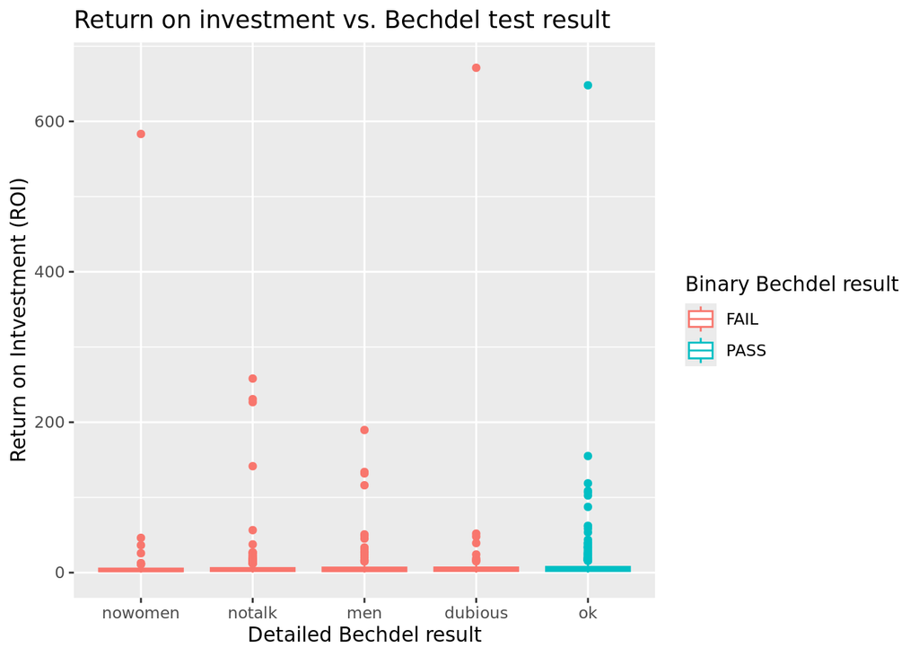

```r
ggplot(data = bechdel90_13,
       mapping = aes(x = clean_test, y = roi, color = binary)) +
  geom_boxplot() +
  labs(
    title = "Return on investment vs. Bechdel test result",
    x = "Detailed Bechdel result",
    y = "Return on Intvestment (ROI)",
    color = "Binary Bechdel result"
  )
```

**Hint:** The y-axis shows the ROI values.

**Task 5.1:** Why is this plot difficult to interpret?

**Your answer:**

The plot is difficult to interpret due to the ROI values being highly skewed and having extreme outliers. Some of the movies have huge ROI values, which makes the y-axis longer and the data gets squished towards zero. This makes the boxplots flat and hard to compare to the ROI across the categories.

## Extreme Observations

What are those movies with *very* high returns on investment?

```r
bechdel90_13 %>%
  filter(roi > 400) %>%
  select(title, budget_2013, domgross_2013, year)
```

```
## # A tibble: 3 × 4
##   title                   budget_2013 domgross_2013  year
##   <chr>                         <int>         <dbl> <int>
## 1 Paranormal Activity          505595     121251476  2007
## 2 The Blair Witch Project      839077     196538593  1999
## 3 El Mariachi                   11622       3388636  1992
```

**Task 5.2:** How many movies have ROI greater than 400?

**Your answer:**

There are 3 movies that have an ROI greater than 400.

**Task 5.3:** What do you notice about the budgets of these high-ROI movies?

**Your answer:**

There budgets are all really small compared to a standard movies budget. This shows how low cost movies can make very bit returns relative to their investment.

## Exercise 6: Zoom In for Better View

Zooming in on the movies with `roi < 15` provides a better view of how the medians across the categories compare.

**Fill in the blanks:**

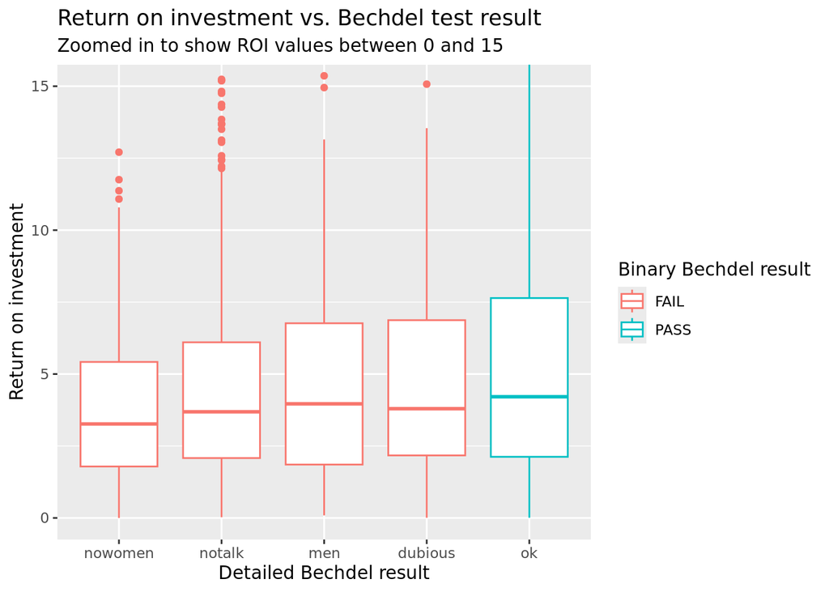

```r
ggplot(data = bechdel90_13,
       mapping = aes(x = clean_test, y = roi, color = binary)) +
  geom_boxplot() +
  labs(
    title = "Return on investment vs. Bechdel test result",
    subtitle = "Zoomed in to show ROI values between 0 and 15", # Something about zooming in to a certain level
    x = "Detailed Bechdel result",
    y = "Return on investment",
    color = "Binary Bechdel result"
  ) +
  coord_cartesian(ylim = c(0, 15))
```

**Hints for subtitle:** - Mention that you’re focusing on ROI < 15 - Something like “Focusing on movies with ROI less than 15” or “Zoomed in to ROI < 15”

**What `coord_cartesian()` does:** - Zooms in on the plot without removing data - `ylim = c(0, 15)`: Shows only y-values from 0 to 15 - Unlike `filter()`, this doesn’t remove data, just changes the view